# R Notebook

Step 1: Clean the Data Task 0: Open RStudio

Task 1: Import your data

```r
nys_acs <- read.csv("~/Documents/NU/Bootcamp/bootcamp-2024/data/nys_acs.csv")
nys_schools <- read.csv("~/Documents/NU/Bootcamp/bootcamp-2024/data/nys_schools.csv")
```

Task 2: Explore your data

```r
str(nys_acs)
```

```
'data.frame':   496 obs. of  5 variables:
 $ county_name            : chr  "ALBANY" "ALBANY" "ALBANY" "ALBANY" ...
 $ year                   : int  2009 2010 2011 2012 2013 2014 2015 2016 2009 2010 ...
 $ county_per_poverty     : num  0.118 0.119 0.121 0.124 0.123 ...
 $ median_household_income: int  55350 56090 57715 59359 59394 59940 59887 60904 40917 41305 ...
 $ county_per_bach        : num  0.19 0.197 0.199 0.198 0.205 ...
```

```r
str(nys_schools)
```

```
'data.frame':   35663 obs. of  12 variables:
 $ school_cd        : num  1.01e+10 1.01e+10 1.01e+10 1.01e+10 1.01e+10 ...
 $ school_name      : chr  "MONTESSORI MAGNET SCHOOL" "MONTESSORI MAGNET SCHOOL" "MONTESSORI MAGNET SCHOOL" "MONTESSORI MAGNET SCHOOL" ...
 $ district_name    : chr  "ALBANY CITY SCHOOL DISTRICT" "ALBANY CITY SCHOOL DISTRICT" "ALBANY CITY SCHOOL DISTRICT" "ALBANY CITY SCHOOL DISTRICT" ...
 $ county_name      : chr  "ALBANY" "ALBANY" "ALBANY" "ALBANY" ...
 $ region           : chr  "CAPITAL DISTRICT" "CAPITAL DISTRICT" "CAPITAL DISTRICT" "CAPITAL DISTRICT" ...
 $ year             : int  2008 2009 2010 2011 2012 2013 2014 2015 2016 2017 ...
 $ total_enroll     : num  316 312 300 326 294 321 335 347 366 359 ...
 $ per_free_lunch   : num  0.33 0.32 0.26 0.22 0.31 0.25 0.35 0.22 0.29 0.26 ...
 $ per_reduced_lunch: num  0.1 0.08 0.08 0.07 0.06 0.08 0.04 0 0.02 0.01 ...
 $ per_lep          : num  0.01 0.02 0.03 0.03 0.03 0.03 0.06 0.06 0.05 0.07 ...
 $ mean_ela_score   : num  658 673 670 667 670 ...
 $ mean_math_score  : num  670 679 683 681 687 ...
```

```r
sum(is.na(nys_schools))
```

```
[1] 0
```

Task 3: Recoding and variable manipulation

1. Deal with missing values, which are currently coded as -99.

```r
for (x in c("total_enroll","per_free_lunch","per_reduced_lunch","per_lep","mean_ela_score","mean_math_score")){
nys_schools[[x]][nys_schools[[x]] == -99] <-mean(nys_schools[[x]][nys_schools[[x]] != -99])}
```

2. Create a categorical variable that groups counties into “high”, “medium”, and “low” poverty groups. Decide how you want to split up the groups and briefly explain your decision.

```r
#sort(table(nys_acs$median_household_income))

quantiles <- quantile(nys_acs$county_per_poverty, probs =seq(0, 1, by = 1/3))

nys_acs$proverty_level<-cut(nys_acs$county_per_poverty,breaks=quantiles, labels=c("high","medium","low"),include.lowest = 'True')
```

3. The tests that the NYS Department of Education administers changes from time to time, so scale scores are not directly comparable year-to-year. Create a new variable that is the standardized z-score for math and English Language Arts (ELA) for each year (hint: group by year and use the scale() function)

```r
scores_std <-nys_schools %>%
  select(year, contains("score")) %>%
  group_by(year) %>%
  summarise(
    ela_mean = mean(mean_ela_score, na.rm = TRUE),
    math_mean = mean(mean_math_score, na.rm = TRUE),
    ela_sd = sd(mean_ela_score, na.rm = TRUE),
    math_sd = sd(mean_math_score, na.rm = TRUE)
  )

school_scale <- inner_join(nys_schools, scores_std, by="year") %>%
  mutate(
    ela_z_score = (mean_ela_score - ela_mean)/ela_sd,
    math_z_score = (mean_math_score - math_mean)/math_sd)%>%
  select(-c(ela_mean, ela_sd, math_mean, math_sd))
```

Task 4: Merge datasets

```r
new_df<-merge(nys_acs, nys_schools, by = c("county_name","year"))
new_df
```

[output not shown]

[output cut: 990 more lines]

```r
nys_county<-nys_schools%>%
group_by(county_name)%>%
  summarise(total_enroll=sum(total_enroll)
            ,per_free_lunch=sum(per_free_lunch)/sum(total_enroll)
            ,per_reduced_lunch=sum(per_reduced_lunch)/sum(total_enroll)
            ,per_lep=sum(per_lep)/sum(total_enroll)
            ,mean_ela_score=mean(mean_ela_score)
            ,mean_math_score=mean(mean_math_score))
nys_county
```

| county_name | total_enroll | per_free_lunch | per_reduced_lunch | per_lep | mean_ela_score | mean_math_score |
| --- | --- | --- | --- | --- | --- | --- |
| -99 | 6284.713 | 0.0017700281 | 2.356995e-04 | 2.659649e-04 | 414.6520 | 422.5704 |
| ALBANY | 257192.000 | 0.0008559364 | 1.325080e-04 | 8.235093e-05 | 485.9718 | 495.2054 |
| ALLEGANY | 55903.000 | 0.0010607660 | 2.917554e-04 | 5.366438e-07 | 491.6627 | 501.3076 |
| BRONX | 1646130.000 | 0.0014361016 | 9.967014e-05 | 3.081652e-04 | 463.9927 | 471.5517 |
| BROOME | 193424.000 | 0.0008616821 | 1.676628e-04 | 4.213541e-05 | 485.2843 | 495.2404 |
| CATTARAUGUS | 93698.000 | 0.0010327862 | 2.614784e-04 | 3.201776e-06 | 496.9010 | 507.2719 |
| CAYUGA | 58462.000 | 0.0008869009 | 1.835380e-04 | 1.402621e-05 | 489.2660 | 502.5143 |
| CHAUTAUQUA | 133285.000 | 0.0012774881 | 2.327344e-04 | 1.003114e-04 | 484.2193 | 494.6951 |
| CHEMUNG | 87757.000 | 0.0008861971 | 1.369691e-04 | 6.495208e-06 | 499.2965 | 508.5743 |
| CHENANGO | 53871.000 | 0.0012459394 | 3.194669e-04 | 3.155687e-06 | 479.4479 | 488.5711 |

[output cut: 53 more lines]

```r
top5_nys_county<-head(nys_county,5)
bottom_5_nys_county<-tail(nys_county,5)
bottom_5_nys_county
```

| county_name | total_enroll | per_free_lunch | per_reduced_lunch | per_lep | mean_ela_score | mean_math_score |
| --- | --- | --- | --- | --- | --- | --- |
| WASHINGTON | 56677 | 0.0009118337 | 2.383683e-04 | 7.057537e-06 | 479.0493 | 485.7067 |
| WAYNE | 99933 | 0.0009325248 | 2.700810e-04 | 3.722494e-05 | 484.7742 | 494.0524 |
| WESTCHESTER | 1042714 | 0.0005779163 | 9.611495e-05 | 1.610363e-04 | 487.5886 | 496.6915 |
| WYOMING | 23123 | 0.0009531635 | 3.208926e-04 | 1.556891e-05 | 497.5867 | 511.7322 |
| YATES | 14686 | 0.0009260520 | 1.940624e-04 | 6.128285e-06 | 478.4833 | 488.3222 |

Task 6: Data visualization 1. The relationship between access to free/reduced price lunch and test performance, at the school level.

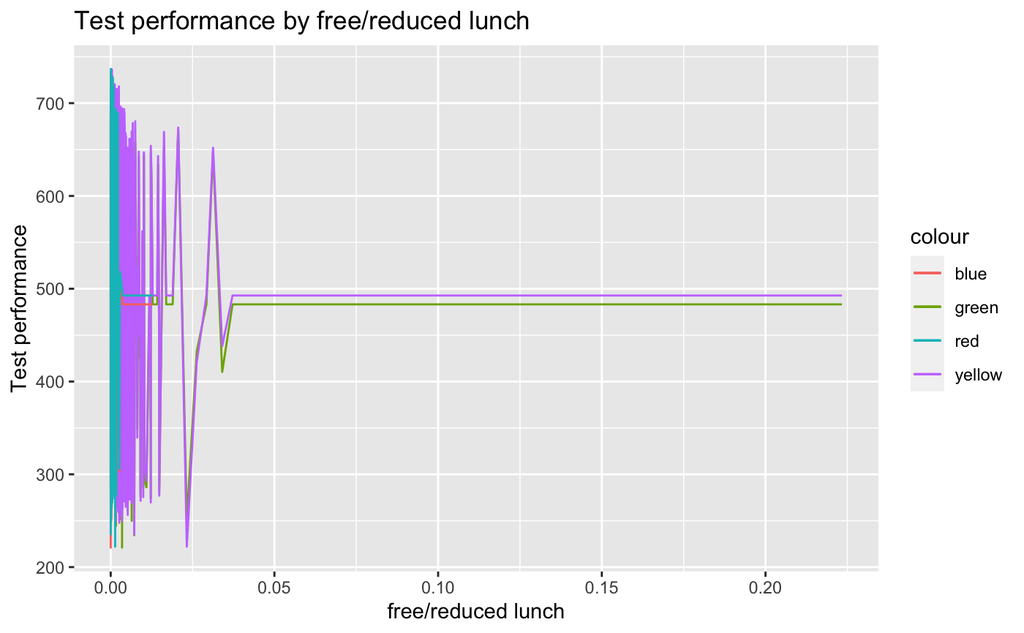

```r
nys_schools %>%
  group_by(school_name) %>%
  summarise(per_free_lunch=sum(per_free_lunch)/sum(total_enroll)
            ,per_reduced_lunch=sum(per_reduced_lunch)/sum(total_enroll)
            ,mean_ela_score=mean(mean_ela_score)
            ,mean_math_score=mean(mean_math_score)) %>%
  ggplot() +
  geom_line(aes(x=per_free_lunch, y=mean_ela_score,col="green")) +
  geom_line(aes(x=per_free_lunch, y=mean_math_score,col="yellow")) +
  geom_line(aes(x=per_reduced_lunch, y=mean_ela_score,col="blue")) +
  geom_line(aes(x=per_reduced_lunch, y=mean_math_score,col="red")) +
  labs(title="Test performance by free/reduced lunch", x="free/reduced lunch", y="Test performance")
```

2.Average test performance across counties with high, low, and medium poverty.

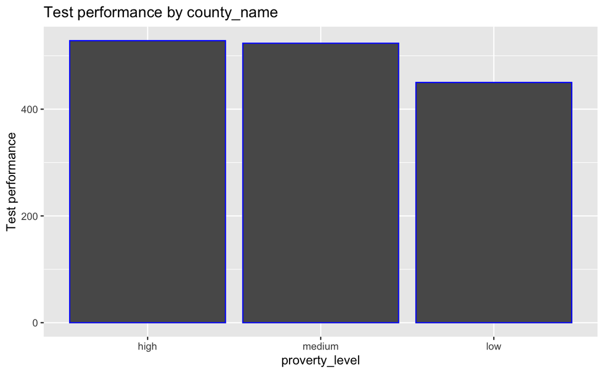

```r
new_df %>%
  group_by(proverty_level) %>%
    summarise(
            mean_ela_score=mean(mean_ela_score)
            ,mean_math_score=mean(mean_math_score)) %>%
  ggplot() +
  geom_col(aes(x=proverty_level, y=mean_ela_score),col="yellow") +
  geom_col(aes(x=proverty_level, y=mean_math_score),col="blue") +
  labs(title="Test performance by county_name", x="proverty_level", y="Test performance")
```